# ( JHU CSSE COVID-19 Data Analysis )

## by (Ziad hany )

## Investigation Overview

> Data Analysis COVID-19 and try to find the relationship between (Confirmed , Deaths , Incidence_Rate ,..) with ( Country_Region , Last Update ,Province_State , ... )

## Dataset Overview

- Daily reports (csse_covid_19_daily_reports)
- USA daily state reports (csse_covid_19_daily_reports_us)
- Time series summary (csse_covid_19_time_series)
- Data modification records
- UID Lookup Table Logic

## (Visualization 1)

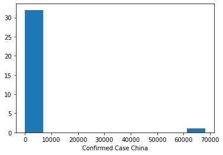

```python
confirmed_china = confirmed_global[confirmed_global['Country/Region'] == 'China']
plt.hist(confirmed_china['9/24/20'])
plt.xlabel('Confirmed Case China');
```

## (Visualization 2)

- The Maximum (Mortality_Rate ) about 70 % in some states in usa And the most common Mortality_Rate is [0 : 10] it is recovered about 90 % of Cov-19

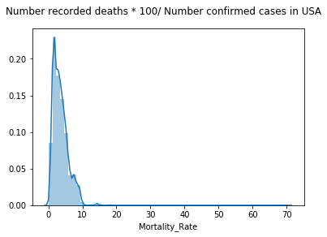

```python
sb.distplot(df1['Mortality_Rate'], bins = 60,  kde=True)
plt.suptitle('Number recorded deaths * 100/ Number confirmed cases in USA')
plt.xlabel('Mortality_Rate');
```

## (Visualization 3)

- `New York , New jersey , Louisiana have the biggest Incidence Rate (cases per 100,000 persons.) in USA`

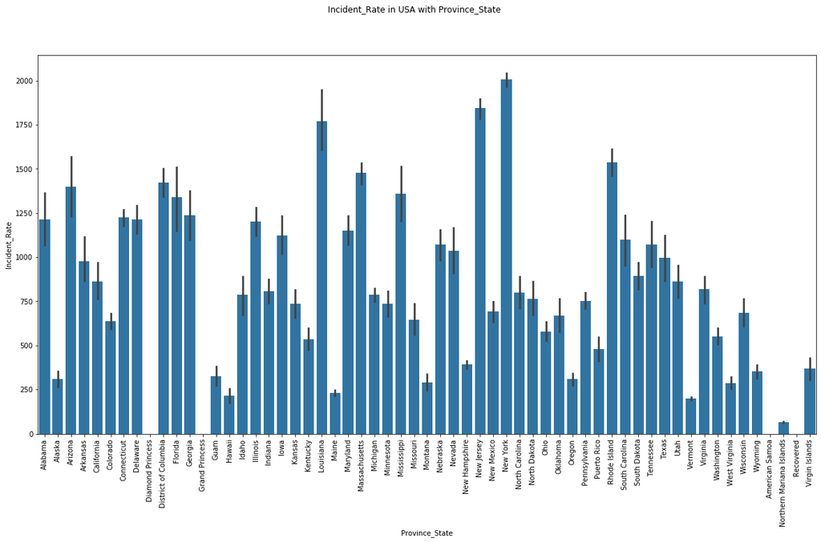

```python
base_color = sb.color_palette()[0]
plt.figure(figsize=(20,10))
sb.barplot(data = df1, x = 'Province_State',y = 'Incident_Rate',color=base_color)
plt.xticks(rotation = 90);
plt.suptitle('Incident_Rate in USA with Province_State');
```

## (Visualization 4)

> The Total number of tested people in ( New york , Alaska , Rhode island ) are slightly bigger than the other states .

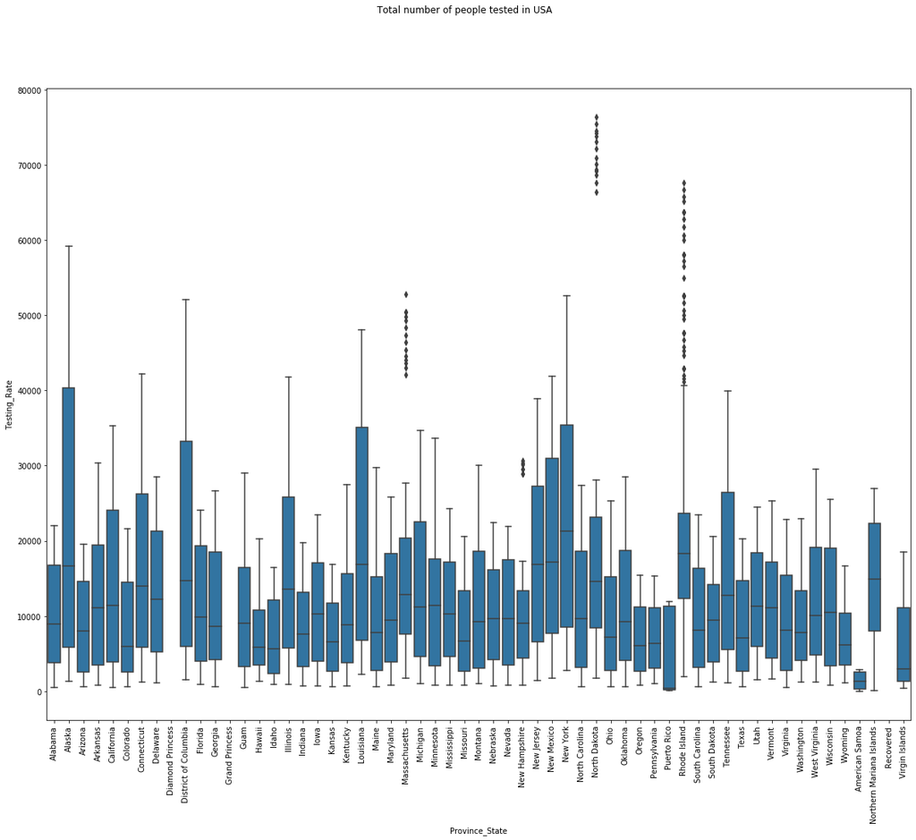

```python
base_color = sb.color_palette()[0]
plt.figure(figsize=(20,15))
sb.boxplot(data = df1, x = 'Province_State', y = 'Testing_Rate', color=base_color)
plt.suptitle('Total number of people tested in USA')
plt.xticks(rotation = 90);
```

## (Visualization 5)

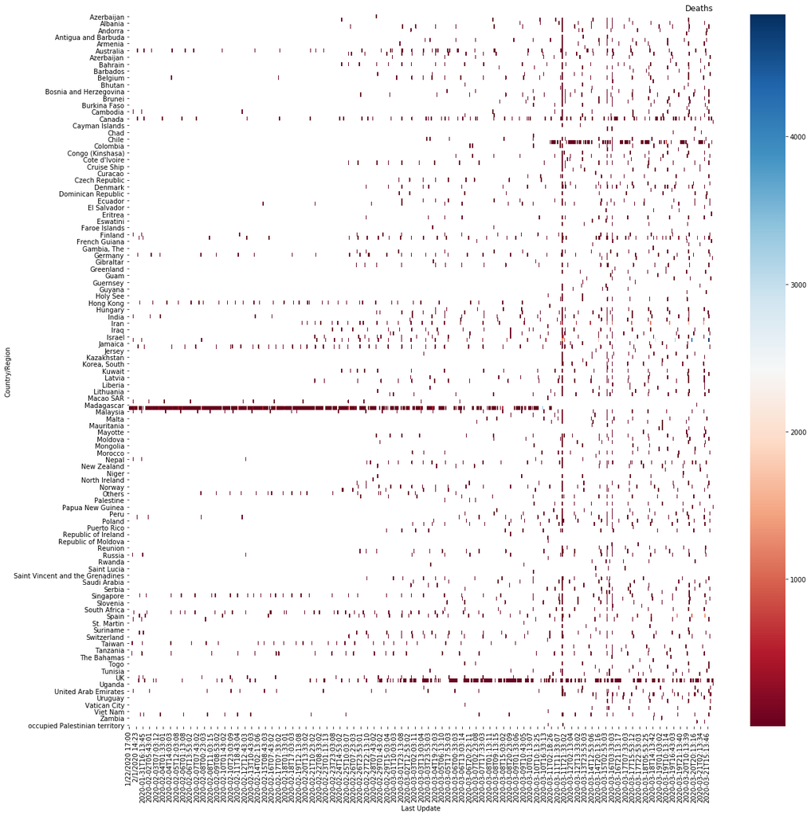

```python
plt.figure(figsize=(20, 20))
heatmap2_data = pd.pivot_table(df,values='Deaths', index=['Country/Region'], columns='Last Update')
heatmap2_data.head(n=5)
sb.heatmap(heatmap2_data, cmap="RdBu")
plt.title('Deaths', loc='right');
```